# Predicting Survival using Titanic Dataset

## Introduction

The Titanic dataset was sourced from [Kaggle](https://www.kaggle.com/competitions/titanic). The dataset includes several variables, such as passenger name, age, class, sex, number of siblings or spouses, number of children or parents aboard, ticket number, fare paid, cabin, and embarkation port. By analysing these features, the aim would be to build a model that can predict survival based on these attributes. The dataset used for this analysis is available in the accompanying GitHub repository.

```r
library(caret)
library(VIM)
library(tidyverse)
library(vcd)
```

## Data Cleaning

A glimpse of the initial dataset shows that Survived and Pclass are integer variables, and Sex and Cabin are character variables. Instead, they should be converted into factors to improve efficiency and allow for the use of levels.

```r
titanic = read.csv("titanic.csv")
glimpse(titanic)
```

```
## Rows: 891
## Columns: 12
## $ PassengerId <int> 1, 2, 3, 4, 5, 6, 7, 8, 9, 10, 11, 12, 13, 14, 15, 16, 17,…
## $ Survived    <int> 0, 1, 1, 1, 0, 0, 0, 0, 1, 1, 1, 1, 0, 0, 0, 1, 0, 1, 0, 1…
## $ Pclass      <int> 3, 1, 3, 1, 3, 3, 1, 3, 3, 2, 3, 1, 3, 3, 3, 2, 3, 2, 3, 3…
## $ Name        <chr> "Braund, Mr. Owen Harris", "Cumings, Mrs. John Bradley (Fl…
## $ Sex         <chr> "male", "female", "female", "female", "male", "male", "mal…
## $ Age         <dbl> 22, 38, 26, 35, 35, NA, 54, 2, 27, 14, 4, 58, 20, 39, 14, …
## $ SibSp       <int> 1, 1, 0, 1, 0, 0, 0, 3, 0, 1, 1, 0, 0, 1, 0, 0, 4, 0, 1, 0…
## $ Parch       <int> 0, 0, 0, 0, 0, 0, 0, 1, 2, 0, 1, 0, 0, 5, 0, 0, 1, 0, 0, 0…
## $ Ticket      <chr> "A/5 21171", "PC 17599", "STON/O2. 3101282", "113803", "37…
## $ Fare        <dbl> 7.2500, 71.2833, 7.9250, 53.1000, 8.0500, 8.4583, 51.8625,…
## $ Cabin       <chr> "", "C85", "", "C123", "", "", "E46", "", "", "", "G6", "C…
## $ Embarked    <chr> "S", "C", "S", "S", "S", "Q", "S", "S", "S", "C", "S", "S"…
```

```r
titanic$Sex = factor(titanic$Sex)
titanic$Cabin = factor(titanic$Cabin)
titanic$Survived = factor(titanic$Survived)
titanic$Pclass = factor(titanic$Pclass)

glimpse(titanic)
```

```
## Rows: 891
## Columns: 12
## $ PassengerId <int> 1, 2, 3, 4, 5, 6, 7, 8, 9, 10, 11, 12, 13, 14, 15, 16, 17,…
## $ Survived    <fct> 0, 1, 1, 1, 0, 0, 0, 0, 1, 1, 1, 1, 0, 0, 0, 1, 0, 1, 0, 1…
## $ Pclass      <fct> 3, 1, 3, 1, 3, 3, 1, 3, 3, 2, 3, 1, 3, 3, 3, 2, 3, 2, 3, 3…
## $ Name        <chr> "Braund, Mr. Owen Harris", "Cumings, Mrs. John Bradley (Fl…
## $ Sex         <fct> male, female, female, female, male, male, male, male, fema…
## $ Age         <dbl> 22, 38, 26, 35, 35, NA, 54, 2, 27, 14, 4, 58, 20, 39, 14, …
## $ SibSp       <int> 1, 1, 0, 1, 0, 0, 0, 3, 0, 1, 1, 0, 0, 1, 0, 0, 4, 0, 1, 0…
## $ Parch       <int> 0, 0, 0, 0, 0, 0, 0, 1, 2, 0, 1, 0, 0, 5, 0, 0, 1, 0, 0, 0…
## $ Ticket      <chr> "A/5 21171", "PC 17599", "STON/O2. 3101282", "113803", "37…
## $ Fare        <dbl> 7.2500, 71.2833, 7.9250, 53.1000, 8.0500, 8.4583, 51.8625,…
## $ Cabin       <fct> , C85, , C123, , , E46, , , , G6, C103, , , , , , , , , , …
## $ Embarked    <chr> "S", "C", "S", "S", "S", "Q", "S", "S", "S", "C", "S", "S"…
```

Moreover, there are Na values in the Age variable in the dataset. By reviewing all occurrences of Na in the dataset, it appears that only Age contains Na values.

```r
colSums(is.na(titanic))
```

```
## PassengerId    Survived      Pclass        Name         Sex         Age
##           0           0           0           0           0         177
##       SibSp       Parch      Ticket        Fare       Cabin    Embarked
##           0           0           0           0           0           0
```

~20% of all rows have Age = Na in the dataset. Hence, removing all rows with Na values would not be an appropriate step.

```r
num_rows = dim(titanic)[1]
177/num_rows
```

```
## [1] 0.1986532
```

Instead, using kNN, all Na values can be imputed instead.

```r
cleaned = kNN(titanic)
head(cleaned)
```

```
##   PassengerId Survived Pclass
## 1           1        0      3
## 2           2        1      1
## 3           3        1      3
## 4           4        1      1
## 5           5        0      3
## 6           6        0      3
##                                                  Name    Sex  Age SibSp Parch
## 1                             Braund, Mr. Owen Harris   male 22.0     1     0
## 2 Cumings, Mrs. John Bradley (Florence Briggs Thayer) female 38.0     1     0
## 3                              Heikkinen, Miss. Laina female 26.0     0     0
## 4        Futrelle, Mrs. Jacques Heath (Lily May Peel) female 35.0     1     0
## 5                            Allen, Mr. William Henry   male 35.0     0     0
## 6                                    Moran, Mr. James   male 28.5     0     0
##             Ticket    Fare Cabin Embarked PassengerId_imp Survived_imp
```

[output cut: 20 more lines]

Additionally, Cabin variable is converted into a binary variable. This is because in the Cabin variable, there are many instances where the passenger’s cabin could not be recorded, and in cases where there were, it does not provide any useful information. Hence, converting cabin into a binary variable could be useful in seeing whether a passenger, having their cabin be successfully recorded, could indicate a higher chance of survival on the Titanic.

```r
cleaned$Cabin = cleaned$Cabin != ""
head(cleaned)
```

```
##   PassengerId Survived Pclass
## 1           1        0      3
## 2           2        1      1
## 3           3        1      3
## 4           4        1      1
## 5           5        0      3
## 6           6        0      3
##                                                  Name    Sex  Age SibSp Parch
## 1                             Braund, Mr. Owen Harris   male 22.0     1     0
## 2 Cumings, Mrs. John Bradley (Florence Briggs Thayer) female 38.0     1     0
## 3                              Heikkinen, Miss. Laina female 26.0     0     0
## 4        Futrelle, Mrs. Jacques Heath (Lily May Peel) female 35.0     1     0
## 5                            Allen, Mr. William Henry   male 35.0     0     0
## 6                                    Moran, Mr. James   male 28.5     0     0
##             Ticket    Fare Cabin Embarked PassengerId_imp Survived_imp
```

[output cut: 20 more lines]

## Exploration Data Analysis

In the bar plot of Cabin Recorded vs Survival Status, the proportion of passengers who survived and had their cabins recorded is much higher than those who did not have their cabins recorded. Moreover, passengers without a recorded cabin are more likely to have perished. This suggests that whether or not a passenger’s cabin was recorded could potentially be a useful predictor of survival. One possible explanation for this trend is that passengers with recorded cabins were likely wealthier individuals who were housed in private cabins. These passengers may have had better access to lifeboats. In contrast, lower-class passengers who did not have their cabins recorded were typically housed in more crowded and less accessible areas of the ship, making it harder for them to reach lifeboats during the disaster.

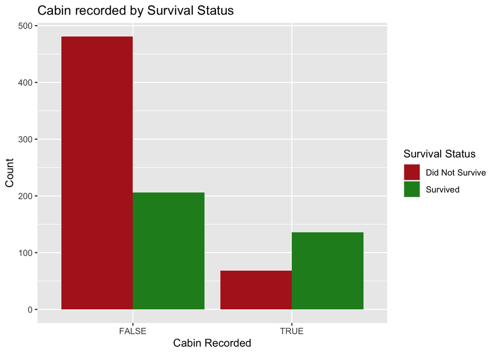

```r
ggplot(cleaned, aes(x = Cabin, fill = Survived)) +
  geom_bar(position = "dodge") +
  labs(title = "Cabin recorded by Survival Status", x = "Cabin Recorded", y = "Count") +
  scale_fill_manual(
    name = "Survival Status",
    values = c("0" = "firebrick", "1" = "forestgreen"),
    labels = c("Did Not Survive", "Survived")
  )
```

In the bar plot of sex vs survival status, a significantly higher proportion of females survived the Titanic compared to males. This suggests that sex could be a strong indicator of survival. One possible explanation for this trend is that women were given higher priority access to lifeboats, as the Titanic’s evacuation protocol favored women and children, which led to a higher survival rate among females.

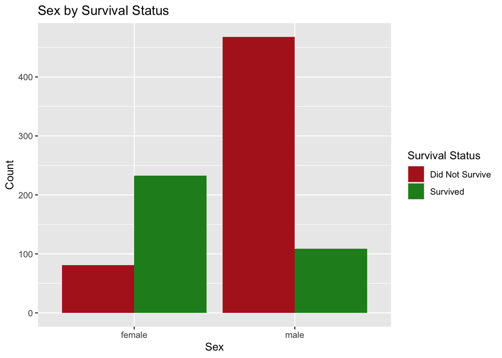

```r
ggplot(cleaned, aes(x = Sex, fill = Survived)) +
  geom_bar(position = "dodge") +
  labs(title = "Sex by Survival Status", x = "Sex", y = "Count") +
  scale_fill_manual(
    name = "Survival Status",
    values = c("0" = "firebrick", "1" = "forestgreen"),
    labels = c("Did Not Survive", "Survived")
  )
```

The bar plot of passenger class and survival rates indicates that those in first class had the highest proportion of survivals. In fact it is the only class where there are more survivors than those who perished. In 2nd class, there were slightly less survivors than those who perished. However, in 3rd class, the vast majority of passengers perished. This trend could be explained by how higher class passengers may have had higher priority in evacuations to life boats.

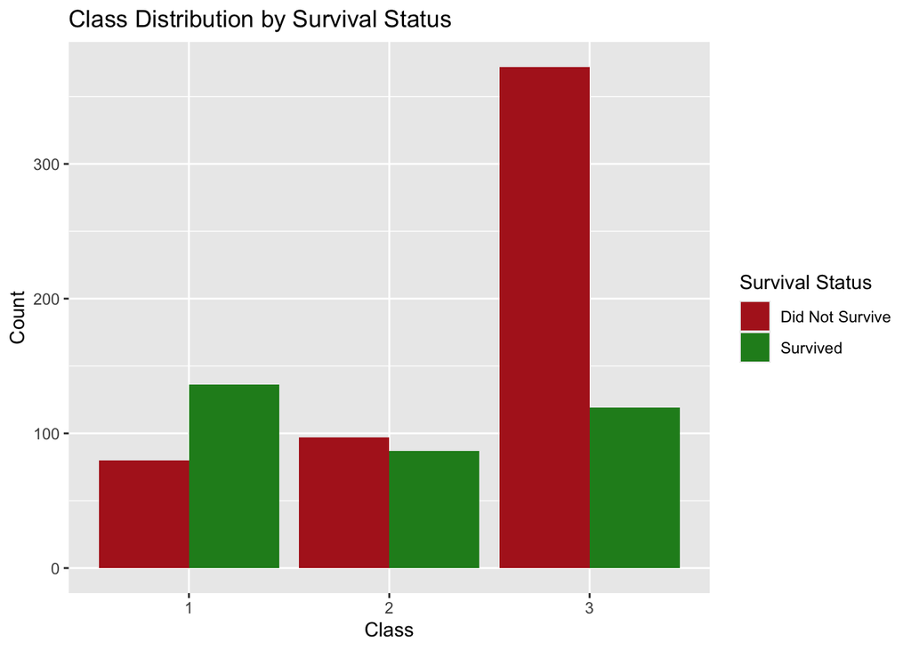

```r
ggplot(cleaned, aes(x = Pclass, fill = Survived)) +
  geom_bar(position = "dodge") +
  labs(title = "Class Distribution by Survival Status", x = "Class", y = "Count") +
  scale_fill_manual(
    name = "Survival Status",
    values = c("0" = "firebrick", "1" = "forestgreen"),
    labels = c("Did Not Survive", "Survived")
  )
```

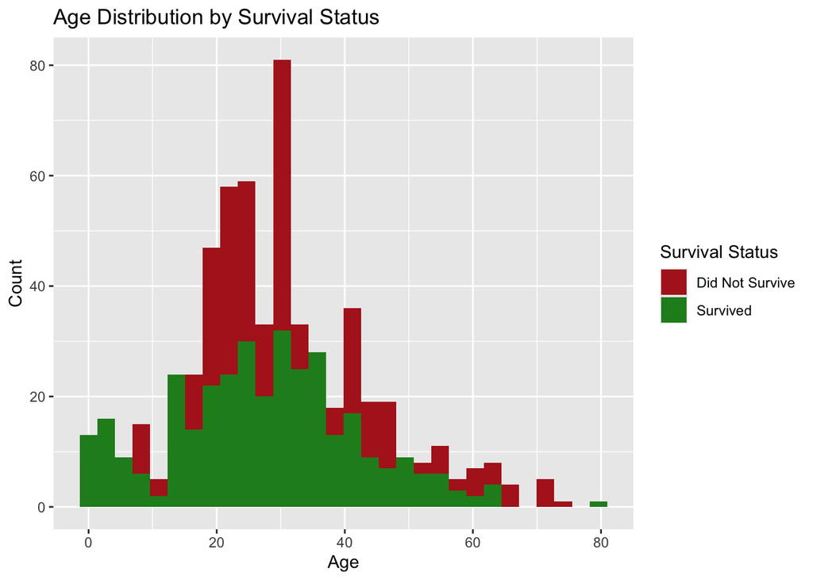

```r
ggplot(cleaned, aes(x = Age, fill = Survived)) +
  geom_histogram(position = "identity", bins = 30) +
  labs(title = "Age Distribution by Survival Status", x = "Age", y = "Count") +
  scale_fill_manual(
    name = "Survival Status",
    values = c("0" = "firebrick", "1" = "forestgreen"),
    labels = c("Did Not Survive", "Survived")
  )
```

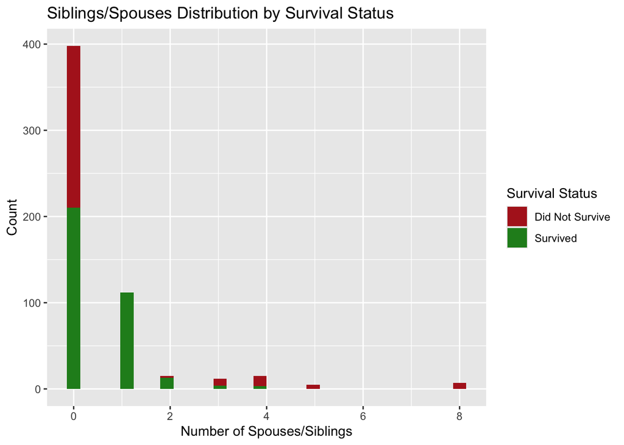

```r
ggplot(cleaned, aes(x = SibSp, fill = Survived)) +
  geom_histogram(position = "identity", bins = 30) +
  labs(title = "Siblings/Spouses Distribution by Survival Status", x = "Number of Spouses/Siblings", y = "Count") +
  scale_fill_manual(
    name = "Survival Status",
    values = c("0" = "firebrick", "1" = "forestgreen"),
    labels = c("Did Not Survive", "Survived")
  )
```

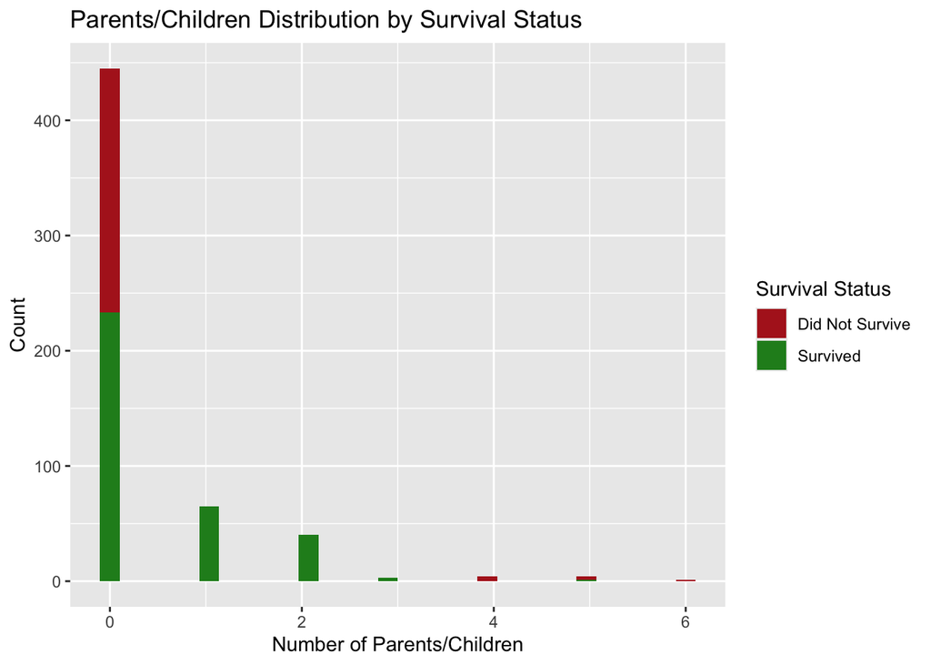

```r
ggplot(cleaned, aes(x = Parch, fill = Survived)) +
  geom_histogram(position = "identity", bins = 30) +
  labs(title = "Parents/Children Distribution by Survival Status", x = "Number of Parents/Children", y = "Count") +
  scale_fill_manual(
    name = "Survival Status",
    values = c("0" = "firebrick", "1" = "forestgreen"),
    labels = c("Did Not Survive", "Survived")
  )
```

The bar plot of fare distribution by survival rates illustrates that those who paid a higher fare had higher survival rates than passengers who paid less. The fare paid by a passenger may also indicate their class, as higher class passengers would have had to a higher fare.

```r
glimpse(cleaned)
```

```
## Rows: 891
## Columns: 24
## $ PassengerId     <int> 1, 2, 3, 4, 5, 6, 7, 8, 9, 10, 11, 12, 13, 14, 15, 16,…
## $ Survived        <fct> 0, 1, 1, 1, 0, 0, 0, 0, 1, 1, 1, 1, 0, 0, 0, 1, 0, 1, …
## $ Pclass          <fct> 3, 1, 3, 1, 3, 3, 1, 3, 3, 2, 3, 1, 3, 3, 3, 2, 3, 2, …
## $ Name            <chr> "Braund, Mr. Owen Harris", "Cumings, Mrs. John Bradley…
## $ Sex             <fct> male, female, female, female, male, male, male, male, …
## $ Age             <dbl> 22.0, 38.0, 26.0, 35.0, 35.0, 28.5, 54.0, 2.0, 27.0, 1…
## $ SibSp           <int> 1, 1, 0, 1, 0, 0, 0, 3, 0, 1, 1, 0, 0, 1, 0, 0, 4, 0, …
## $ Parch           <int> 0, 0, 0, 0, 0, 0, 0, 1, 2, 0, 1, 0, 0, 5, 0, 0, 1, 0, …
## $ Ticket          <chr> "A/5 21171", "PC 17599", "STON/O2. 3101282", "113803",…
## $ Fare            <dbl> 7.2500, 71.2833, 7.9250, 53.1000, 8.0500, 8.4583, 51.8…
## $ Cabin           <lgl> FALSE, TRUE, FALSE, TRUE, FALSE, FALSE, TRUE, FALSE, F…
## $ Embarked        <chr> "S", "C", "S", "S", "S", "Q", "S", "S", "S", "C", "S",…
## $ PassengerId_imp <lgl> FALSE, FALSE, FALSE, FALSE, FALSE, FALSE, FALSE, FALSE…
## $ Survived_imp    <lgl> FALSE, FALSE, FALSE, FALSE, FALSE, FALSE, FALSE, FALSE…
## $ Pclass_imp      <lgl> FALSE, FALSE, FALSE, FALSE, FALSE, FALSE, FALSE, FALSE…
## $ Name_imp        <lgl> FALSE, FALSE, FALSE, FALSE, FALSE, FALSE, FALSE, FALSE…
## $ Sex_imp         <lgl> FALSE, FALSE, FALSE, FALSE, FALSE, FALSE, FALSE, FALSE…
## $ Age_imp         <lgl> FALSE, FALSE, FALSE, FALSE, FALSE, TRUE, FALSE, FALSE,…
## $ SibSp_imp       <lgl> FALSE, FALSE, FALSE, FALSE, FALSE, FALSE, FALSE, FALSE…
## $ Parch_imp       <lgl> FALSE, FALSE, FALSE, FALSE, FALSE, FALSE, FALSE, FALSE…
## $ Ticket_imp      <lgl> FALSE, FALSE, FALSE, FALSE, FALSE, FALSE, FALSE, FALSE…
## $ Fare_imp        <lgl> FALSE, FALSE, FALSE, FALSE, FALSE, FALSE, FALSE, FALSE…
## $ Cabin_imp       <lgl> FALSE, FALSE, FALSE, FALSE, FALSE, FALSE, FALSE, FALSE…
## $ Embarked_imp    <lgl> FALSE, FALSE, FALSE, FALSE, FALSE, FALSE, FALSE, FALSE…
```

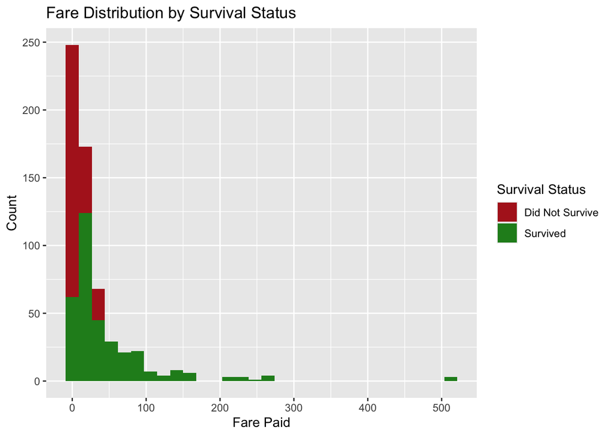

```r
ggplot(cleaned, aes(x = Fare, fill = Survived)) +
  geom_histogram(position = "identity", bins = 30) +
  labs(title = "Fare Distribution by Survival Status", x = "Fare Paid", y = "Count") +
  scale_fill_manual(
    name = "Survival Status",
    values = c("0" = "firebrick", "1" = "forestgreen"),
    labels = c("Did Not Survive", "Survived")
  )
```

The below bar plot of fare distribution by passenger class demonstrates a clear relationship where those who paid more belonged to higher classes. Thus, those who had higher fares and were more likely to survived mostly belonged to higher classes, where it had already been established that those who belonged to higher classes had higher survival rates. Given this strong correlation between `Fare` and `Pclass`, the `Fare` variable may not be essential in the predictive model as it essentially acts as a proxy for `Pclass`.

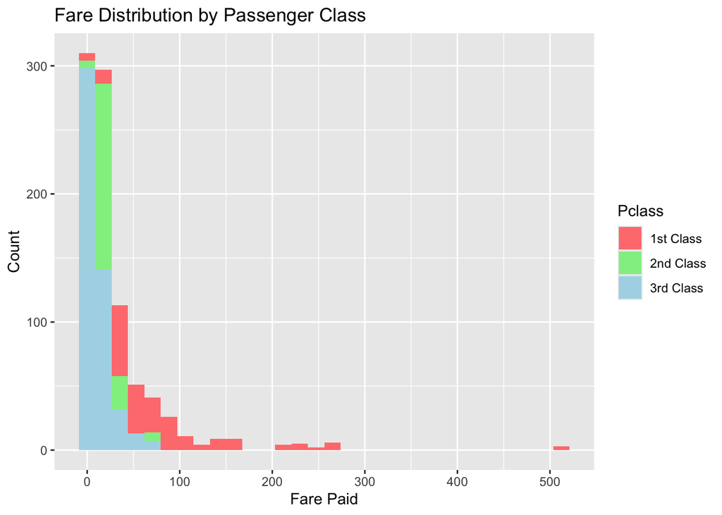

```r
ggplot(cleaned, aes(x = Fare, fill = Pclass)) +
  geom_histogram(position = "stack", bins = 30) +
  labs(title = "Fare Distribution by Passenger Class", x = "Fare Paid", y = "Count") +
  scale_fill_manual(
    name = "Pclass",
    values = c("1" = "#FF7F7F", "2" = "#90EE90", "3" = "#ADD8E6"),
    labels = c("1st Class", "2nd Class", "3rd Class")
  )
```

Before graphing the `Embarked` variable, some rows were found to have empty strings. Hence, the rows with empty strings were removed before the `Embarked` variable was graphed against the `Survived` variable, however, the original dataset will still have the rows where `Embarked` is an empty string.

The bar plot below indicates that those who embarked at C had a higher proportion of survival compared to those who embarked elsewhere. Hence, this variable may have some use in predicting survival.

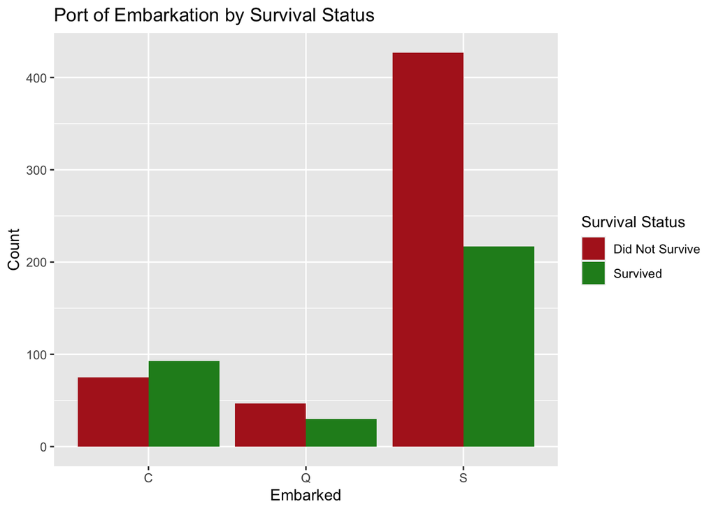

```r
clean_embarked = cleaned |> filter(Embarked != "")

ggplot(clean_embarked, aes(x = Embarked, fill = Survived)) +
  geom_bar(position = "dodge") +
  labs(title = "Port of Embarkation by Survival Status", x = "Embarked", y = "Count") +
  scale_fill_manual(
    name = "Survival Status",
    values = c("0" = "firebrick", "1" = "forestgreen"),
    labels = c("Did Not Survive", "Survived")
  )
```

To statistically evaluate the association between each of the above variables to survival, a Chi-squared test of Independence will be used to determine whether these variables are independent to `Survived`. If so, then Cramer’s V will be calculated for each variable to determine the strength of the association.

```r
cleaned$AgeBracket = cut(
  cleaned$Age,
  breaks = c(0, 10, 20, 30, 40, 50, 60, Inf),
  right = TRUE,
  include.lowest = TRUE
)

cleaned$SibSpBracket = cut(
  cleaned$SibSp,
  breaks = c(-1, 0, 1, 2, 3, Inf),
  right = TRUE
)

cleaned$ParchBracket = cut(
  cleaned$Parch,
  breaks = c(-1, 0, 1, 2, Inf),
  right = TRUE
)

cleaned$FareBracket = cut(
  cleaned$Fare,
  breaks = c(seq(from = 0, to = 95, by = 10), Inf),
  right = TRUE,
  include.lowest = TRUE
)
```

In summary, after running the Chi-squared test, all variables achieved a p-value of less than 0.05, suggesting that each variable is not independent of survival. Below is a summary of the results ranked by Cramer’s V:

[output not shown]

```r
variables = c("Cabin", "SibSpBracket", "AgeBracket", "Sex", "Pclass", "ParchBracket", "FareBracket")

for (variable in variables) {
  cat("\n\n", paste("Comparing", variable, "vs Survival"), "\n\n")
  cont_table = table(cleaned[[variable]], cleaned$Survived)
  names(dimnames(cont_table)) = c(variable, "Survived")
  print(cont_table)
  cat("\n")
  test = chisq.test(cont_table)
  assoc = assocstats(cont_table)
  cat("P-value:", test$p.value, "\n")
  cat("Cramér's V:", round(assoc$cramer, 4), "\n")
  cat("\n")
}
```

```
##
##
##  Comparing Cabin vs Survival
##
##        Survived
## Cabin     0   1
##   FALSE 481 206
##   TRUE   68 136
##
## P-value: 6.74197e-21
## Cramér's V: 0.3169
##
##
##
##  Comparing SibSpBracket vs Survival
##
##             Survived
## SibSpBracket   0   1
##      (-1,0]  398 210
##      (0,1]    97 112
##      (1,2]    15  13
##      (2,3]    12   4
##      (3,Inf]  27   3
##
## P-value: 2.364607e-07
## Cramér's V: 0.2022
##
##
##
##  Comparing AgeBracket vs Survival
##
##           Survived
## AgeBracket   0   1
##   [0,10]    31  44
##   (10,20]   78  62
##   (20,30]  194  96
##   (30,40]  133  83
##   (40,50]   64  35
##   (50,60]   28  17
##   (60,Inf]  21   5
```

[output cut: 47 more lines]

```
##            Survived
## FareBracket   0   1
##    [0,10]   269  67
##    (10,20]  103  76
##    (20,30]   79  63
##    (30,40]   35  23
##    (40,50]   12   4
##    (50,60]   11  27
##    (60,70]   11   6
##    (70,80]   12  19
##    (80,90]    3  14
##    (90,Inf]  14  43
##
## P-value: 1.963923e-22
## Cramér's V: 0.3732
```

```r
cat("\n\nEmbarkation vs Survival\n\n")
```

```
##
##
## Embarkation vs Survival
```

```r
cont_table = table(clean_embarked$Embarked, clean_embarked$Survived)
names(dimnames(cont_table)) = c("Embarked", "Survived")
test = chisq.test(cont_table)
assoc = assocstats(cont_table)
print(cont_table)
```

```
##         Survived
## Embarked   0   1
##        C  75  93
##        Q  47  30
##        S 427 217
```

```r
cat("\n")
```

```r
cat("P-value:", test$p.value, "\n")
```

```
## P-value: 1.769922e-06
```

```r
cat("Cramér's V:", round(assoc$cramer, 4), "\n")
```

```
## Cramér's V: 0.1726
```

## Modeling

Finally, the dataset was split into training and testing subsets to enable model evaluation on unseen data.

```r
cleaned = cleaned |> select(Cabin, SibSp, Age, Sex, Pclass, Parch, Survived)
train_index = createDataPartition(cleaned$Survived, p = 0.8, list = FALSE)
train_data = cleaned[train_index, ]
test_data = cleaned[-train_index, ]
```

[output not shown]

```r
knn_model = train(
  Survived ~ .,
  data = train_data,
  method = "knn",
  tuneLength = 20,
  trControl = trainControl(method = "cv", number = 10),
  preProcess = c("center", "scale")
)
knn_model
```

```
## k-Nearest Neighbors
##
## 714 samples
##   6 predictor
##   2 classes: '0', '1'
##
## Pre-processing: centered (7), scaled (7)
## Resampling: Cross-Validated (10 fold)
## Summary of sample sizes: 642, 643, 643, 643, 642, 642, ...
## Resampling results across tuning parameters:
##
##   k   Accuracy   Kappa
##    5  0.8263302  0.6256185
##    7  0.8025626  0.5726411
##    9  0.8081964  0.5819475
##   11  0.8320227  0.6329423
##   13  0.8194249  0.6072602
##   15  0.8151995  0.5979710
##   17  0.8193858  0.6085923
##   19  0.8179577  0.6033752
##   21  0.8263693  0.6219775
##   23  0.8207551  0.6080923
##   25  0.8277191  0.6239193
##   27  0.8221244  0.6124811
##   29  0.8276995  0.6233824
##   31  0.8290884  0.6272089
##   33  0.8305164  0.6295339
##   35  0.8305556  0.6299678
##   37  0.8249413  0.6182764
##   39  0.8221635  0.6116762
##   41  0.8221440  0.6114838
##   43  0.8221440  0.6122623
##
## Accuracy was used to select the optimal model using the largest value.
## The final value used for the model was k = 11.
```

```r
knn_pred = predict(knn_model, test_data)
conf_matrix = table(Predicted = knn_pred, Actual = test_data$Survived)

cat("\n")
```

```r
print(conf_matrix)
```

```
##          Actual
## Predicted  0  1
##         0 90 24
##         1 19 44
```

```r
cat("\n")
```

```r
accuracy = sum(diag(conf_matrix)) / sum(conf_matrix)
cat("Accuracy: ", round(accuracy, 4), "\n")
```

```
## Accuracy:  0.7571
```

```r
svm_model = train(
  Survived ~ .,
  data = train_data,
  method = "svmRadial",
  trControl = trainControl(method = "cv", number = 10),
  preProcess = c("center", "scale"),
  tuneLength = 10
)
svm_model
```

```
## Support Vector Machines with Radial Basis Function Kernel
##
## 714 samples
##   6 predictor
##   2 classes: '0', '1'
##
## Pre-processing: centered (7), scaled (7)
## Resampling: Cross-Validated (10 fold)
## Summary of sample sizes: 642, 643, 642, 643, 642, 643, ...
## Resampling results across tuning parameters:
##
##   C       Accuracy   Kappa
##     0.25  0.8374804  0.6446377
##     0.50  0.8417058  0.6558454
##     1.00  0.8304969  0.6307875
##     2.00  0.8151604  0.5996110
##     4.00  0.8109155  0.5912176
##     8.00  0.8066901  0.5826092
##    16.00  0.8053208  0.5794841
##    32.00  0.8080986  0.5862870
##    64.00  0.8053599  0.5795774
##   128.00  0.8053991  0.5810068
##
## Tuning parameter 'sigma' was held constant at a value of 0.4382246
## Accuracy was used to select the optimal model using the largest value.
## The final values used for the model were sigma = 0.4382246 and C = 0.5.
```

```r
svm_pred = predict(svm_model, test_data)
conf_matrix = table(Predicted = svm_pred, Actual = test_data$Survived)

cat("\n")
```

```r
print(conf_matrix)
```

```
##          Actual
## Predicted  0  1
##         0 96 26
##         1 13 42
```

```r
cat("\n")
```

```r
accuracy = sum(diag(conf_matrix)) / sum(conf_matrix)
cat("Accuracy: ", round(accuracy, 4), "\n")
```

```
## Accuracy:  0.7797
```

```r
tree_model = train(
  Survived ~ .,
  data = train_data,
  method = "rpart",
  trControl = trainControl(method = "cv", number = 10),
  preProcess = c("center", "scale"),
  tuneLength = 10
)
tree_model
```

```
## CART
##
## 714 samples
##   6 predictor
##   2 classes: '0', '1'
##
## Pre-processing: centered (7), scaled (7)
## Resampling: Cross-Validated (10 fold)
## Summary of sample sizes: 643, 642, 642, 643, 643, 643, ...
## Resampling results across tuning parameters:
##
##   cp          Accuracy   Kappa
##   0.00000000  0.8194836  0.6052464
##   0.05231144  0.7970462  0.5639211
##   0.10462287  0.7970462  0.5639211
##   0.15693431  0.7970462  0.5639211
##   0.20924574  0.7970462  0.5639211
##   0.26155718  0.7970462  0.5639211
##   0.31386861  0.7970462  0.5639211
##   0.36618005  0.7970462  0.5639211
##   0.41849148  0.7970462  0.5639211
##   0.47080292  0.6861111  0.2374988
##
## Accuracy was used to select the optimal model using the largest value.
## The final value used for the model was cp = 0.
```

```r
tree_pred = predict(tree_model, test_data)
conf_matrix = table(Predicted = tree_pred, Actual = test_data$Survived)

cat("\n")
```

```r
print(conf_matrix)
```

```
##          Actual
## Predicted  0  1
##         0 97 22
##         1 12 46
```

```r
cat("\n")
```

```r
accuracy = sum(diag(conf_matrix)) / sum(conf_matrix)
cat("Accuracy: ", round(accuracy, 4), "\n")
```

```
## Accuracy:  0.8079
```